```python
%load_ext autoreload
%autoreload 2
%matplotlib inline
```

```python
import numpy as np
import matplotlib.pyplot as plt
from hottbox.core import Tensor

from matplotlib import rc
## for Palatino and other serif fonts use:
# rc('font',**{'family':'serif','serif':['Palatino']})
rc('text', usetex=True)
rc('lines', linewidth=2)
rc('pdf',compression=0)
rc('figure', figsize= [6.4, 2.9], dpi=300, ) # figure size is in inches
rc('font',size=16)
rc('axes', grid=True)

saveFig = False
```

Return to Table of Contents

# Tensors and basic operations

[figure not shown]

A tensor is a multi-dimenaional array of data where each dimension is conventionally referred to as the **mode**. Tensor order is defined by the number of its modes which is equivivalent to the number of indices required to identify a particular entry of a multi-dimensional array. For ease of visualisation and compact notation, we consider a third order tensor $\mathbf{\underline{X}} \in \mathbb{R}^{I \times J \times K}$. Thus, an element of such a tensor, $\mathbf{\underline{X}} \in \mathbb{R}^{I \times J \times K}$, can be written in a general form as:

$$ x_{ijk} = \mathbf{\underline{X}}[i, j, k]$$

> **Note:** In order to be consistent with Python indexing, count of modes and elements within starts from zeros.

Creation of a tensor starts with a formation of a multidimensional array of data.

```python
# Create 3-d array of data
array_3d = np.arange(24).reshape((2, 3, 4))

# Create tensor
tensor = Tensor(array_3d)

# Result preview
print(tensor)
tensor.data
```

```
This tensor is of order 3 and consists of 24 elements.
Sizes and names of its modes are (2, 3, 4) and ['mode-0', 'mode-1', 'mode-2'] respectively.
```

```
array([[[ 0,  1,  2,  3],
        [ 4,  5,  6,  7],
        [ 8,  9, 10, 11]],

       [[12, 13, 14, 15],
        [16, 17, 18, 19],
        [20, 21, 22, 23]]])
```

## **Assigment 1**

### Solution: Part 1

```python
# Create a tensor
# Create 5-d array of data
dimensions = (2, 3, 4, 5, 6);
elementsNeeded = np.prod(dimensions)
array_5d = 5*np.ones(elementsNeeded).reshape(dimensions)

# Create tensor
tensor5d = Tensor(array_5d)

# Result preview
print(tensor)
tensor5d.data
```

```
This tensor is of order 3 and consists of 24 elements.
Sizes and names of its modes are (2, 3, 4) and ['mode-0', 'mode-1', 'mode-2'] respectively.
```

```
array([[[[[5., 5., 5., 5., 5., 5.],
          [5., 5., 5., 5., 5., 5.],
          [5., 5., 5., 5., 5., 5.],
          [5., 5., 5., 5., 5., 5.],
          [5., 5., 5., 5., 5., 5.]],

         [[5., 5., 5., 5., 5., 5.],
          [5., 5., 5., 5., 5., 5.],
          [5., 5., 5., 5., 5., 5.],
          [5., 5., 5., 5., 5., 5.],
          [5., 5., 5., 5., 5., 5.]],

         [[5., 5., 5., 5., 5., 5.],
          [5., 5., 5., 5., 5., 5.],
          [5., 5., 5., 5., 5., 5.],
          [5., 5., 5., 5., 5., 5.],
          [5., 5., 5., 5., 5., 5.]],

         [[5., 5., 5., 5., 5., 5.],
          [5., 5., 5., 5., 5., 5.],
          [5., 5., 5., 5., 5., 5.],
          [5., 5., 5., 5., 5., 5.],
          [5., 5., 5., 5., 5., 5.]]],


        [[[5., 5., 5., 5., 5., 5.],
          [5., 5., 5., 5., 5., 5.],
          [5., 5., 5., 5., 5., 5.],
          [5., 5., 5., 5., 5., 5.],
          [5., 5., 5., 5., 5., 5.]],

         [[5., 5., 5., 5., 5., 5.],
          [5., 5., 5., 5., 5., 5.],
          [5., 5., 5., 5., 5., 5.],
          [5., 5., 5., 5., 5., 5.],
          [5., 5., 5., 5., 5., 5.]],

         [[5., 5., 5., 5., 5., 5.],
          [5., 5., 5., 5., 5., 5.],
          [5., 5., 5., 5., 5., 5.],
```

[output cut: 94 more lines]

```
          [5., 5., 5., 5., 5., 5.],
          [5., 5., 5., 5., 5., 5.],
          [5., 5., 5., 5., 5., 5.]],

         [[5., 5., 5., 5., 5., 5.],
          [5., 5., 5., 5., 5., 5.],
          [5., 5., 5., 5., 5., 5.],
          [5., 5., 5., 5., 5., 5.],
          [5., 5., 5., 5., 5., 5.]],

         [[5., 5., 5., 5., 5., 5.],
          [5., 5., 5., 5., 5., 5.],
          [5., 5., 5., 5., 5., 5.],
          [5., 5., 5., 5., 5., 5.],
          [5., 5., 5., 5., 5., 5.]]]]])
```

```python
# Calculate Frobenious norm
np.linalg.norm(array_5d) # numpy
tensor.frob_norm # inbuilt
```

```
65.75712889109438
```

### Solution: Part 2

```python
# Create tensors and collect information
x = np.arange(3,20+1) # +1 as it does upto, not including
y = np.power(2,x)
```

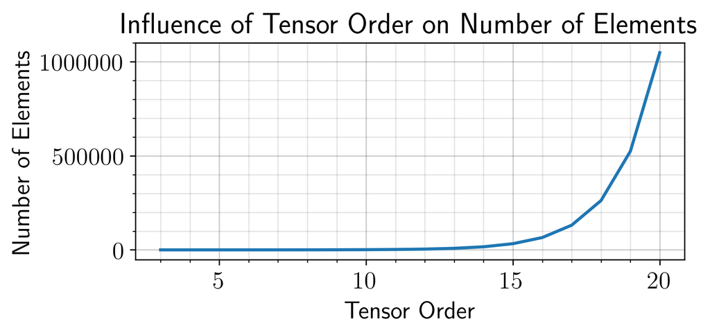

```python
# Plot results
plt.plot(x,y)

plt.xlabel(r'Tensor Order')
plt.ylabel(r'Number of Elements',fontsize=16)
plt.title(r" Influence of Tensor Order on Number of Elements ")
# Make room for the ridiculously large title.
plt.subplots_adjust(top=0.8)

plt.minorticks_on()
plt.grid(b=True, which='major', color='k', linestyle='-', alpha=0.2)
plt.grid(b=True, which='minor', color='k', linestyle='-', alpha=0.1)
plt.show()

if saveFig:
    plt.savefig('../figures/Q5_TD_BD_5_2.pdf',format='pdf', bbox_inches="tight")
```

### Solution: Part 3

```python
# Create tensors and collect information
x2 = np.arange(3,20+1) # +1 as it does upto, not including
y2 = np.power(x2,3)
```

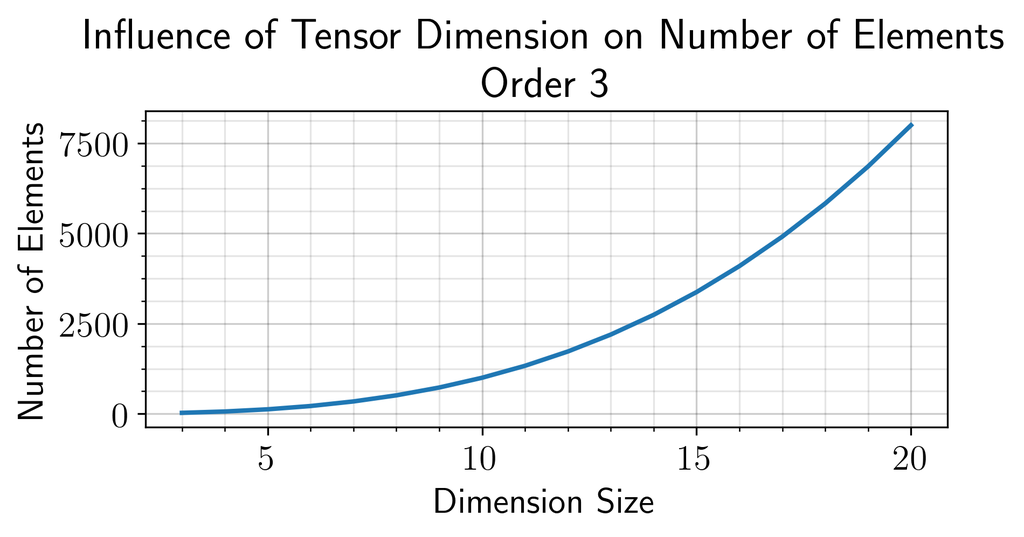

```python
# Plot results
plt.plot(x2,y2)

plt.xlabel(r'Dimension Size')
plt.ylabel(r'Number of Elements',fontsize=16)
plt.title(" Influence of Tensor Dimension on Number of Elements \n Order 3 ")
# Make room for the ridiculously large title.
plt.subplots_adjust(top=0.8)

plt.minorticks_on()
plt.grid(b=True, which='major', color='k', linestyle='-', alpha=0.2)
plt.grid(b=True, which='minor', color='k', linestyle='-', alpha=0.1)
plt.show()

if saveFig:
    plt.savefig('../figures/Q5_TD_BD_5_3.pdf',format='pdf', bbox_inches="tight")
```

### Solution: Part 4

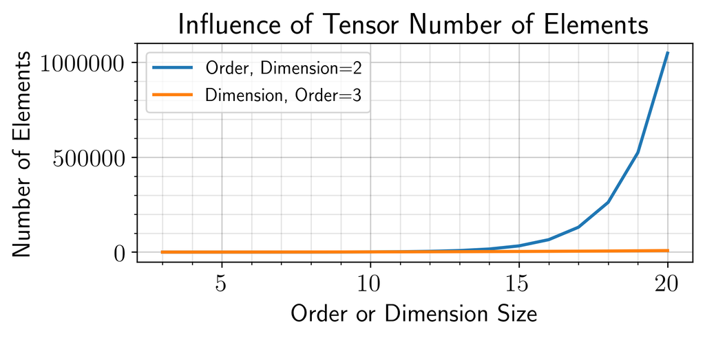

```python
orderSweep, = plt.plot(x,y, label='Order, Dimension=2')
dimensionSweep = plt.plot(x2,y2, label='Dimension, Order=3')

plt.xlabel(r'Order or Dimension Size')
plt.ylabel(r'Number of Elements',fontsize=16)
plt.title(r" Influence of Tensor Number of Elements ")
# Make room for the ridiculously large title.
plt.subplots_adjust(top=0.8)

plt.minorticks_on()
plt.grid(b=True, which='major', color='k', linestyle='-', alpha=0.2)
plt.grid(b=True, which='minor', color='k', linestyle='-', alpha=0.1)
plt.legend(fontsize=12)
plt.show()
```

It is quite clear that the effect Tensor order is more significant

# Most common tensor substructures

[figure not shown]

1. A **fiber** is a vector obtained by fixing all but one of the indices, e.g. $\mathbf{\underline{X}}[i,:,k]$ is the mode-2 fiber $\mathbf{\underline{X}}$ (usually refered to as row fiber).
2. Fixing all but two of the indices yields a matrix called a **slice** of a tensor, e.g. $\mathbf{\underline{X}}[:,:,k]$ is the mode-[1,2] slice (usually refered to as the frontal slice).

**Note:** The same principles and definitions can be applied to a tensor of an arbitrarily large order. In addition, you can obtain a **subtensor** by fixing at least three indices and letting the remaining ones vary.

**NOTE:** The above image and explanations uses 1-indexing, whereas python is 0 indexed. This meas that mode-[1,2] is actually mode-[0,1] in the python indexing world. https://github.com/IlyaKisil/dpm-coursework/issues/1 https://github.com/IlyaKisil/dpm-coursework/issues/2

```python
# Mode-2 fiber
# tensor.data[0,1,:]
tensor.data[0,:,1]
```

```
array([1, 5, 9])
```

```python
# Frontal slice
# tensor.data[0,:,:]
tensor.data[:,:,0] # \
```

```
array([[ 0,  4,  8],
       [12, 16, 20]])
```

## **Assigment 2**

1. Create a tensor of order 4 which consists of 81 elements and display all its horizontal slices and any five row fibers.
2. Create a tensor of order 3 and shape `(4,2,5)`, where the values of each consequent frontal slice are doubled.

### Solution: Part 1

```python
# Create a tensor of order 4
order = 4
dimension = np.power(81,1/4)
array_4d = np.arange(81).reshape([dimension.astype(int)]*order)

tensor4d = Tensor(array_4d)
print(tensor4d)
```

```
This tensor is of order 4 and consists of 81 elements.
Sizes and names of its modes are (3, 3, 3, 3) and ['mode-0', 'mode-1', 'mode-2', 'mode-3'] respectively.
```

```python
# Display (horizontal) slices
for x in range(0,dimension.astype(int)):
    print('\t\t\t\t Slice {}'.format(x))
    print(tensor4d.data[x,:,:,:])
```

```
				 Slice 0
[[[ 0  1  2]
  [ 3  4  5]
  [ 6  7  8]]

 [[ 9 10 11]
  [12 13 14]
  [15 16 17]]

 [[18 19 20]
  [21 22 23]
  [24 25 26]]]
				 Slice 1
[[[27 28 29]
  [30 31 32]
  [33 34 35]]

 [[36 37 38]
  [39 40 41]
  [42 43 44]]

 [[45 46 47]
  [48 49 50]
  [51 52 53]]]
				 Slice 2
[[[54 55 56]
  [57 58 59]
  [60 61 62]]

 [[63 64 65]
  [66 67 68]
  [69 70 71]]

 [[72 73 74]
  [75 76 77]
  [78 79 80]]]
```

```python
# Display (row) fibers
for x in range(0,dimension.astype(int)):
    print('\t\t\t\t Fibre {}'.format(x))
    print(tensor4d.data[1,:,1,x])

for x in range(0,dimension.astype(int)):
    print('\t\t\t\t Fibre {}'.format(x+3))
    print(tensor4d.data[1,:,0,x])
```

```
				 Fibre 0
[30 39 48]
				 Fibre 1
[31 40 49]
				 Fibre 2
[32 41 50]
				 Fibre 3
[27 36 45]
				 Fibre 4
[28 37 46]
				 Fibre 5
[29 38 47]
```

### Solution: Part 2

```python
# Create a tensor of order 3
order = 3
dimension = (4,2,5)

elementList = np.ones( (dimension[0],dimension[1],1) ) # 3D Slice 4 by 2 by 1
for x in range(1,dimension[2]):
    elementList = np.concatenate( ( elementList, np.ones( (dimension[0],dimension[1],1) )*np.power(2,int(x)) ), axis=2 )

array_3d_2 = elementList.reshape(dimension) # not really necessary

tensor3d_2 = Tensor(array_3d_2)

print(tensor3d_2)

# Display (frontal) slices
print('\n Frontal Slices')
for x in range(0,dimension[2]):
    print('\t\t\t\t Slice {}'.format(x))
    print(tensor3d_2.data[:,:,x])
```

```
This tensor is of order 3 and consists of 40 elements.
Sizes and names of its modes are (4, 2, 5) and ['mode-0', 'mode-1', 'mode-2'] respectively.

 Frontal Slices
				 Slice 0
[[1. 1.]
 [1. 1.]
 [1. 1.]
 [1. 1.]]
				 Slice 1
[[2. 2.]
 [2. 2.]
 [2. 2.]
 [2. 2.]]
				 Slice 2
[[4. 4.]
 [4. 4.]
 [4. 4.]
 [4. 4.]]
				 Slice 3
[[8. 8.]
 [8. 8.]
 [8. 8.]
 [8. 8.]]
				 Slice 4
[[16. 16.]
 [16. 16.]
 [16. 16.]
 [16. 16.]]
```

# Unfolding

Conventionally, unfolding is considered to be a process of element mapping from a tensor to a matrix. In other words, it arranges the mode-$n$ fibers of a tensor to be the matrix columns. Thus, the mode-$n$ unfolding is denoted as:

$$\mathbf{\underline{A}} \xrightarrow{n} \mathbf{A}_{(n)}$$

Thus, this operations requires to specify a mode along which a tensor will be unfolded. For a third order tensor, a visual representation of such operation is as following

[figure not shown]

In `hottbox` this functionality is available through the corresponding methods of the `Tensor` object, for instance:

```python
# Create 3-d array of data
array_3d = np.arange(24).reshape((2, 3, 4))

print('Orignal Matrix \n', array_3d,'\n')

# Create tensor
tensor = Tensor(array_3d)

# Unfolding of a tensor
tensor.unfold(mode=0)

# Result preview
print(tensor)
print(tensor.data)
```

```
Orignal Matrix
 [[[ 0  1  2  3]
  [ 4  5  6  7]
  [ 8  9 10 11]]

 [[12 13 14 15]
  [16 17 18 19]
  [20 21 22 23]]]

This tensor is of order 2 and consists of 24 elements.
Sizes and names of its modes are (2, 12) and ['mode-0', 'mode-1_mode-2'] respectively.
[[ 0  1  2  3  4  5  6  7  8  9 10 11]
 [12 13 14 15 16 17 18 19 20 21 22 23]]
```

## **Assigment 3**

1. Create a tensor, $\mathbf{\underline{A}}$, of order 4, in such a way that its version unfolded along the second mode would have sizes `(5,72)`, that is $\mathbf{A}_{(n)} \in \mathbb{R}^{5 \times 72}$. Validate your results by displaying the unfolded tensor.

### Solution : Part 1

```python
# Create 4-d array of data
array_4d = np.arange(5*72).reshape((18, 5, 2, 2))
# mode=1 unfold, hence the second dimension (dimension index 1), should be 5
# arbritrarily set the dimensions of the others such that their product was 72

# print('Orignal Matrix \n', array_4d,'\n')

# Create tensor
tensor = Tensor(array_4d)

# Unfolding of a tensor
tensor.unfold(mode=1)

# Result preview
print(tensor)
```

```
This tensor is of order 2 and consists of 360 elements.
Sizes and names of its modes are (5, 72) and ['mode-1', 'mode-0_mode-2_mode-3'] respectively.
```

```python
# Display unfolded version
print(tensor.data)
```

```
[[  0   1   2   3  20  21  22  23  40  41  42  43  60  61  62  63  80  81
   82  83 100 101 102 103 120 121 122 123 140 141 142 143 160 161 162 163
  180 181 182 183 200 201 202 203 220 221 222 223 240 241 242 243 260 261
  262 263 280 281 282 283 300 301 302 303 320 321 322 323 340 341 342 343]
 [  4   5   6   7  24  25  26  27  44  45  46  47  64  65  66  67  84  85
   86  87 104 105 106 107 124 125 126 127 144 145 146 147 164 165 166 167
  184 185 186 187 204 205 206 207 224 225 226 227 244 245 246 247 264 265
  266 267 284 285 286 287 304 305 306 307 324 325 326 327 344 345 346 347]
 [  8   9  10  11  28  29  30  31  48  49  50  51  68  69  70  71  88  89
   90  91 108 109 110 111 128 129 130 131 148 149 150 151 168 169 170 171
  188 189 190 191 208 209 210 211 228 229 230 231 248 249 250 251 268 269
  270 271 288 289 290 291 308 309 310 311 328 329 330 331 348 349 350 351]
 [ 12  13  14  15  32  33  34  35  52  53  54  55  72  73  74  75  92  93
   94  95 112 113 114 115 132 133 134 135 152 153 154 155 172 173 174 175
  192 193 194 195 212 213 214 215 232 233 234 235 252 253 254 255 272 273
  274 275 292 293 294 295 312 313 314 315 332 333 334 335 352 353 354 355]
 [ 16  17  18  19  36  37  38  39  56  57  58  59  76  77  78  79  96  97
   98  99 116 117 118 119 136 137 138 139 156 157 158 159 176 177 178 179
  196 197 198 199 216 217 218 219 236 237 238 239 256 257 258 259 276 277
  278 279 296 297 298 299 316 317 318 319 336 337 338 339 356 357 358 359]]
```

# Mode-n product

[figure not shown]

The mode-$n$ product is a multiplication of a tensor by a matrix along the $n^{th}$ mode of a tensor. This essentially means that each mode-$n$ fiber should be multiplied by this matrix. Mathematically, this can be expressed as:

$$\mathbf{\underline{X}} \times_n \mathbf{A} = \mathbf{\underline{Y}} \quad \Leftrightarrow \quad \mathbf{Y}_{(n)} = \mathbf{A} \mathbf{X}_{(n)} $$

```python
I, J, K = 2, 3, 4
J_new = 5

# Create tensor
array_3d = np.arange(I * J * K).reshape(I, J ,K)
X = Tensor(array_3d)
X2 = Tensor(array_3d)

# Create matrix
A = np.arange(J_new * J).reshape(J_new, J)

# Performs Mode-n product
Y = X.mode_n_product(A, mode=1, inplace=False) # Setting inplace=False, mean we DO NOT change X2 itself

Y2 = X2.mode_n_product(A, mode=1, inplace=True) # Setting inplace=True (default), mean we change X2 itself

# Preview of resulting tensor
print('Y:', Y)

# Preview of its unfolded version
print('False Inplace, X: \n', X.unfold(mode=1, inplace=False).data, '\n')

print('Y2:', Y2)
print('True Inplace, X: \n', X2.unfold(mode=1, inplace=False).data, '\n')
```

```
Y: This tensor is of order 3 and consists of 40 elements.
Sizes and names of its modes are (2, 5, 4) and ['mode-0', 'mode-1', 'mode-2'] respectively.
False Inplace, X:
 [[ 0  1  2  3 12 13 14 15]
 [ 4  5  6  7 16 17 18 19]
 [ 8  9 10 11 20 21 22 23]]

Y2: This tensor is of order 3 and consists of 40 elements.
Sizes and names of its modes are (2, 5, 4) and ['mode-0', 'mode-1', 'mode-2'] respectively.
True Inplace, X:
 [[ 20  23  26  29  56  59  62  65]
 [ 56  68  80  92 200 212 224 236]
 [ 92 113 134 155 344 365 386 407]
 [128 158 188 218 488 518 548 578]
 [164 203 242 281 632 671 710 749]]
```

## **Assignment 4**

1. Perform the mode-$n$ product of a 3-rd order tensor, $\mathbf{\underline{X}}$, with a matrix, $\mathbf{A} \in \mathbb{R}^{5 \times 4}$, provided that the resulting tensor, $\mathbf{\underline{Y}}$, consists of `100` elements. Validate your results.

> **Note:** You are encouraged to experiment with the optional parameter `inplace` and to investigate its effect on the result.

### Solution: Part 1

```python
# Create original tensor
# X with I,J,K
# If a   mode-0     mode-1      mode-2   product:
# A with I_new,I    J_new,J    K_new,K
# In all cases the remaining 2 dimensions have a total of 100/5=20 elements

# Create matrix
I, J, K = 2, 4, 10
J_new = 5

# Create tensor
array_3d = np.arange(I * J * K).reshape(I, J ,K)
X = Tensor(array_3d)
```

```python
# Create matrix
A = np.arange(J_new * J).reshape(J_new, J)
```

```python
# Performs Mode-n product
Y = X.mode_n_product(A, mode=1, inplace=False)

print(Y)
```

```
This tensor is of order 3 and consists of 100 elements.
Sizes and names of its modes are (2, 5, 10) and ['mode-0', 'mode-1', 'mode-2'] respectively.
```

```python
# Validate equivalence between the left and right hand side
print(Y.data)
```

```
[[[ 140  146  152  158  164  170  176  182  188  194]
  [ 380  402  424  446  468  490  512  534  556  578]
  [ 620  658  696  734  772  810  848  886  924  962]
  [ 860  914  968 1022 1076 1130 1184 1238 1292 1346]
  [1100 1170 1240 1310 1380 1450 1520 1590 1660 1730]]

 [[ 380  386  392  398  404  410  416  422  428  434]
  [1260 1282 1304 1326 1348 1370 1392 1414 1436 1458]
  [2140 2178 2216 2254 2292 2330 2368 2406 2444 2482]
  [3020 3074 3128 3182 3236 3290 3344 3398 3452 3506]
  [3900 3970 4040 4110 4180 4250 4320 4390 4460 4530]]]
```

# Properties of mode-n product

1. For distinct modes in a series of multiplications, the order of the multiplication is irrelevent:

   $$\mathbf{\underline{X}} \times_n \mathbf{A} \times_m \mathbf{B} = \mathbf{\underline{X}} \times_m \mathbf{B} \times_n \mathbf{A} \quad (m \neq n)$$
2. However, this does not hold if the modes are the same :

   $$\mathbf{\underline{X}} \times_n \mathbf{A} \times_n \mathbf{B} = \mathbf{\underline{X}} \times_n (\mathbf{B}\mathbf{A})$$

## **Assignment 5**

1. Validate both of the above properties empirically
2. Prove the second property analytically

> **Note:** Be aware of consequences of the optional parameter `inplace` (its default value is set to `True`).

### Solution: Part 1

```python
# Create tensor
I, J, K = 2, 3, 4
J_new = 5
K_new = 2

# Create tensor
array_3d = np.arange(I * J * K).reshape(I, J ,K)
X = Tensor(array_3d)
```

```python
# Create matrices
A = np.arange(J_new * J).reshape(J_new, J)

B = np.arange(K_new * K).reshape(K_new, K)

B2 = np.arange(K_new * J).reshape(K_new, J)
B3 = np.arange(K_new * J_new).reshape(K_new, J_new)
```

```python
# Validate property 1
Y1 = X.mode_n_product(A, mode=1, inplace=False).mode_n_product(B, mode=2, inplace=False)
Y2 = X.mode_n_product(B, mode=2, inplace=False).mode_n_product(A, mode=1, inplace=False)
np.testing.assert_array_equal(Y1.data, Y2.data)
print('The underlying data of Y1 and Y2 are completely equal.')
```

```
The underlying data of Y1 and Y2 are completely equal.
```

```python
# Validate property 2
Y3 = X.mode_n_product(A, mode=1, inplace=False).mode_n_product(B3, mode=1, inplace=False)
Y4 = X.mode_n_product( np.dot(B3,A) , mode=1, inplace=False)
np.testing.assert_array_equal(Y1.data, Y2.data)
print('The underlying data of Y3 and Y4 are completely equal.')
```

```
The underlying data of Y3 and Y4 are completely equal.
```

### Solution: Part 2

Use [LaTeX syntax](https://stackoverflow.com/questions/13208286/how-to-write-latex-in-ipython-notebook) for analytical deriviations for the second property below.

The intuition being this result is when we are multiplying the nth mode we are taking each mode-n slice of the tensor and applying the matrix product.

For a 3rd order tensor this can be understood as taking a 2D slice - i.e. a matrix.

With this matrix standard size and order rules apply.

Hence on the RHS BA have dimensions $J_{new_B}\times J$ from the matrix product of:

$$\mathbf{B}_{J_{new_B}\times J_{new_A}}\mathbf{A}_{J_{new_A}\times J} = (BA)_{J_{new_B}\times J}$$

```python
%%latex
$$\mathbf{\underline{X}} \times_n \mathbf{A} \times_n \mathbf{B} = \mathbf{\underline{X}} \times_n (\mathbf{B}\mathbf{A})$$
$$\mathbf{\underline{X}} \times_n \mathbf{A} = \mathbf{\underline{Y}} \quad \Leftrightarrow  \quad \mathbf{Y}_{(n)} = \mathbf{A} \mathbf{X}_{(n)}  $$
\begin{align}
\mathbf{\underline{X}}_{I\times J \times K}
\end{align}
```

$$\mathbf{\underline{X}} \times_n \mathbf{A} \times_n \mathbf{B} = \mathbf{\underline{X}} \times_n (\mathbf{B}\mathbf{A})$$ $$\mathbf{\underline{X}} \times_n \mathbf{A} = \mathbf{\underline{Y}} \quad \Leftrightarrow \quad \mathbf{Y}_{(n)} = \mathbf{A} \mathbf{X}_{(n)} $$ \begin{align} \mathbf{\underline{X}}_{I\times J \times K} \end{align}